# eda_preprocessing

```python
import numpy as np
np.random.seed(123)
import pandas as pd
import matplotlib.pyplot as plt
import seaborn as sns
import warnings
warnings.simplefilter('ignore')
%matplotlib inline
# plt.rcParams['figure.figsize'] = (8,6)
sns.set_style('whitegrid')
import time
```

```python
# train = pd.read_csv('train.csv')
# test = pd.read_csv('test.csv')
```

```python
# test['id'].to_pickle('id_pickle')
```

```python
train = pd.read_pickle('original_train_pickle')
test = pd.read_pickle('original_test_pickle')
```

# column descriptions

**experiment_week** : The column identifying the week during which the data was collected

**channel_type** : The channel through which the product is being sold, such as ‘Warehouse Retailers’, ‘grocery stores’, etc.

**num_units_sold_in_week**: Number of units of the particular product sold that week

**sales_revenue_in_week**: Revenue that the company made by the sale of the products

**num_units_returned**: The number of units returned by the retailer for the products sold that week. (Sometimes due to the retailers stocking the products for longer and returning products purchased from prior weeks this variable might be higher than the num_units_sold_in_week)

**returned_units_revenue_loss**: The amount of money that the company paid the retailer for returning the product

**store_identifier**: Anonymized identifier of the retailer

**product_identifier**: Product key from the database

**category_of_route**: Type of route used by the supplier to deliver the products

**supplier_identifier**: Anonymized identifier of the supplier distributing the product to the retailer. Most stores have a single supplier, sometimes a store might have two suppliers.

**demand_projection**: This is the target attribute, that you are supposed to generate. You should generate the demand for the number of units for a product by subtracting the number of units returned from the number of units sold

```python
sample = train.sample(6, random_state=123)
sample
```

|  | experiment_week | channel_type | num_units_sold_in_week | sales_revenue_in_week | num_units_returned | returned_units_revenue_loss | store_identifier | product_identifier | category_of_route | supplier_identifier |
| --- | --- | --- | --- | --- | --- | --- | --- | --- | --- | --- |
| 25301786 | Week 3 of 2019 | Grocery Stores | 15 | 1188.00 | 0 | 0.0 | store_90145 | product_d31ff | route_77459 | supplier_identifier_92933 |
| 5479903 | Week 1 of 2019 | Supermarkets | 15 | 4401.00 | 0 | 0.0 | store_70618 | product_42d99 | route_5e534 | supplier_identifier_e5252 |
| 21438442 | Week 2 of 2019 | Grocery Stores | 2 | 202.80 | 0 | 0.0 | store_24daa | product_046e4 | route_eeafc | supplier_identifier_7e9ce |
| 53011103 | Week 5 of 2019 | Grocery Stores | 5 | 468.75 | 0 | 0.0 | store_f1641 | product_cf1a6 | route_46ddd | supplier_identifier_2a69e |
| 12533637 | Week 2 of 2019 | Grocery Stores | 1 | 152.10 | 0 | 0.0 | store_23168 | product_57d8e | route_fca13 | supplier_identifier_c2847 |
| 34466 | Week 1 of 2019 | Grocery Stores | 7 | 472.50 | 0 | 0.0 | store_35fcf | product_fa9b1 | route_f8a5d | supplier_identifier_0ffe1 |

```python
train.info()
```

```
<class 'pandas.core.frame.DataFrame'>
RangeIndex: 53364883 entries, 0 to 53364882
Data columns (total 10 columns):
experiment_week                category
channel_type                   category
num_units_sold_in_week         int64
sales_revenue_in_week          float64
num_units_returned             int64
returned_units_revenue_loss    float64
store_identifier               category
product_identifier             category
category_of_route              category
supplier_identifier            category
dtypes: category(6), float64(2), int64(2)
memory usage: 2.2 GB
```

```python
# # convert object to category dtype
# for col in train.select_dtypes(object).columns:
#     train[col] = train[col].astype('category')
```

```python
# # convert object to category dtype
# for col in test.select_dtypes(object).columns:
#     test[col] = test[col].astype('category')
```

```python
# train.to_pickle('original_train_pickle')
# test.to_pickle('original_test_pickle')
```

```python
train.info()
```

```
<class 'pandas.core.frame.DataFrame'>
RangeIndex: 53364883 entries, 0 to 53364882
Data columns (total 10 columns):
experiment_week                category
channel_type                   category
num_units_sold_in_week         int64
sales_revenue_in_week          float64
num_units_returned             int64
returned_units_revenue_loss    float64
store_identifier               category
product_identifier             category
category_of_route              category
supplier_identifier            category
dtypes: category(6), float64(2), int64(2)
memory usage: 2.2 GB
```

```python
train.isna().sum()
```

```
experiment_week                0
channel_type                   0
num_units_sold_in_week         0
sales_revenue_in_week          0
num_units_returned             0
returned_units_revenue_loss    0
store_identifier               0
product_identifier             0
category_of_route              0
supplier_identifier            0
dtype: int64
```

```python
train['demand_projection'] = train['num_units_sold_in_week'] - train['num_units_returned']
train.drop(['num_units_sold_in_week', 'num_units_returned'], axis=1, inplace=True)
```

```python
train.describe()
```

|  | sales_revenue_in_week | returned_units_revenue_loss | demand_projection |
| --- | --- | --- | --- |
| count | 5.336488e+07 | 5.336488e+07 | 5.336488e+07 |
| mean | 1.027445e+03 | 1.219568e+00 | 7.180995e+00 |
| std | 5.128563e+03 | 3.932746e+01 | 2.207857e+01 |
| min | 0.000000e+00 | 0.000000e+00 | -1.634500e+04 |
| 25% | 2.514000e+02 | 0.000000e+00 | 2.000000e+00 |
| 50% | 4.500000e+02 | 0.000000e+00 | 3.000000e+00 |
| 75% | 8.437500e+02 | 0.000000e+00 | 6.000000e+00 |
| max | 9.710400e+06 | 1.307600e+05 | 5.000000e+03 |

```python
train.select_dtypes('category').describe()
```

|  | experiment_week | channel_type | store_identifier | product_identifier | category_of_route | supplier_identifier |
| --- | --- | --- | --- | --- | --- | --- |
| count | 53364883 | 53364883 | 53364883 | 53364883 | 53364883 | 53364883 |
| unique | 5 | 9 | 587773 | 1736 | 3490 | 552 |
| top | Week 1 of 2019 | Grocery Stores | store_384b1 | product_1c00e | route_3b474 | supplier_identifier_dc4bc |
| freq | 11165207 | 48547255 | 88430 | 1560863 | 337586 | 582417 |

# Exploratory data analysis

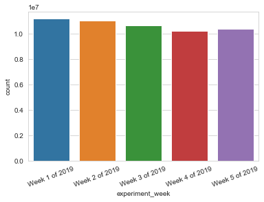

```python
# how much weekly data is available with us?
sns.countplot(x='experiment_week', data=train)
plt.xticks(rotation=20)
plt.show()
# data seems fairly evenly distributed
```

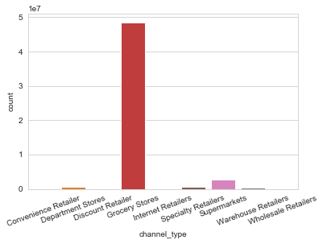

```python
# same for channel data
sns.countplot(x='channel_type', data=train)
plt.xticks(rotation=20)
plt.show()
# most data is from grocery stores
```

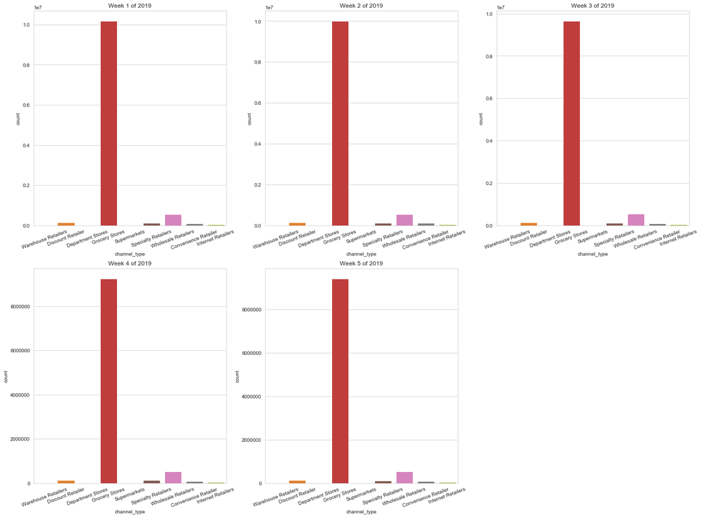

```python
fig, ax = plt.subplots(2, 3, figsize=(23, 17))
ax = ax.flatten()
for i, j in enumerate(train['experiment_week'].unique()):
    data = train.loc[train['experiment_week'] == j]
    sns.countplot(x='channel_type', data=data, ax=ax[i])
    ax[i].set_title(j)
    ax[i].set_xticklabels(rotation=20, labels=data['channel_type'].unique())
ax[5].axis('off')
plt.show()
# previous observation is true across all weeks
```

```python
# create a new column to capture profit/loss
train['net_revenue'] = train['sales_revenue_in_week'] - train['returned_units_revenue_loss']
```

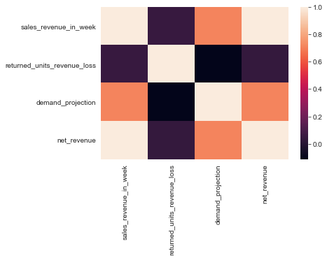

```python
# column correlations of numeric data
sns.heatmap(train.corr())
plt.show()
```

demand and net revenue are closely correlated, which makes sense, while returned units revenue does not seem to correlate with either demand projection or net revenue

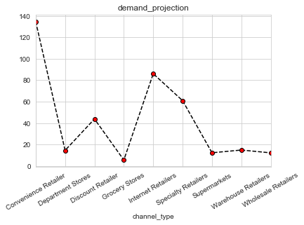

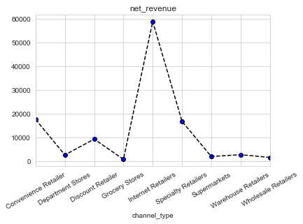

```python
# channel wise demand and revenue
temp1 = train.groupby(['channel_type']).mean()['demand_projection']
temp1.plot(marker='o', markerfacecolor='red', linestyle='dashed', color='black')
plt.xticks(rotation=30)
plt.title('demand_projection')
plt.show()

temp2 = train.groupby(['channel_type']).mean()['net_revenue']
temp2.plot(marker='o', markerfacecolor='blue', linestyle='dashed', color='black')
plt.xticks(rotation=30)
plt.title('net_revenue')
plt.show()
```

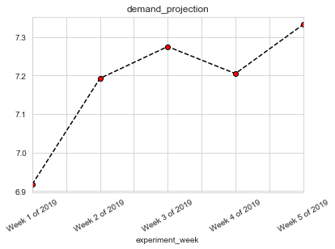

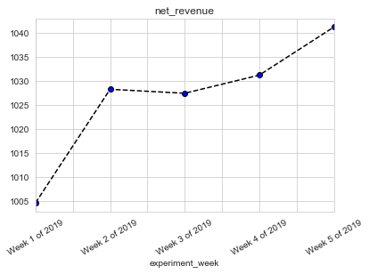

```python
# channel wise demand and revenue
temp1 = train.groupby(['experiment_week']).mean()['demand_projection']
temp1.plot(marker='o', markerfacecolor='red', linestyle='dashed', color='black')
plt.xticks(rotation=30)
plt.title('demand_projection')
plt.show()

temp2 = train.groupby(['experiment_week']).mean()['net_revenue']
temp2.plot(marker='o', markerfacecolor='blue', linestyle='dashed', color='black')
plt.xticks(rotation=30)
plt.title('net_revenue')
plt.show()
```

# Weekly data analysis

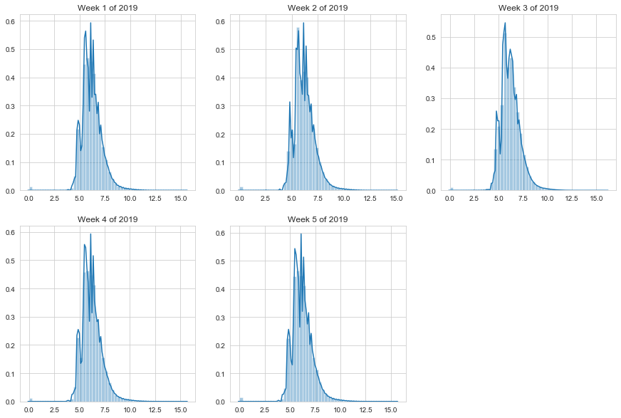

```python
fig, ax = plt.subplots(2,3,figsize=(15,10))
ax = ax.flatten()
for i in enumerate(sorted(train['experiment_week'].unique())):
    sns.distplot(np.log([x+1 for x in train.loc[train['experiment_week'] == i[1], 'sales_revenue_in_week']]), ax=ax[i[0]])
    ax[i[0]].set_title(i[1])
ax[5].axis('off')
plt.show()
```

almost a normal distribution, all slightly positively skewed

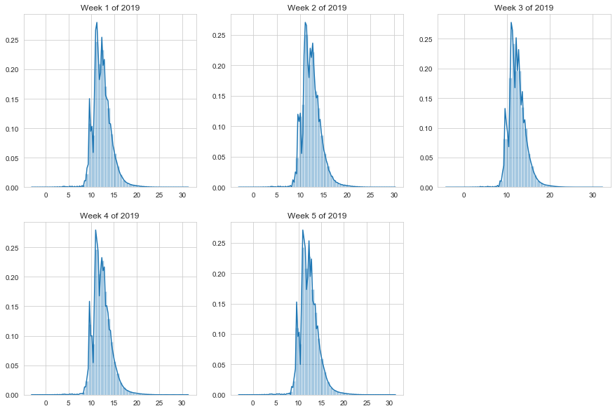

```python
fig, ax = plt.subplots(2,3,figsize=(15,10))
ax = ax.flatten()
for i in enumerate(sorted(train['experiment_week'].unique())):
    sns.distplot(np.log(np.square([x+1 for x in train.loc[train['experiment_week'] == i[1], 'net_revenue']])), ax=ax[i[0]])
    ax[i[0]].set_title(i[1])
ax[5].axis('off')
plt.show()
```

the profit distribution closely mirrors sales revenue, which makes sense considering how it was derived (return revenue loss was mostly 0)

# Analysis of channels

```python
temp = []
for week in sorted(set(train['experiment_week'])):
    temp.append(train.groupby(['experiment_week', 'channel_type']).mean()['net_revenue'][week])
```

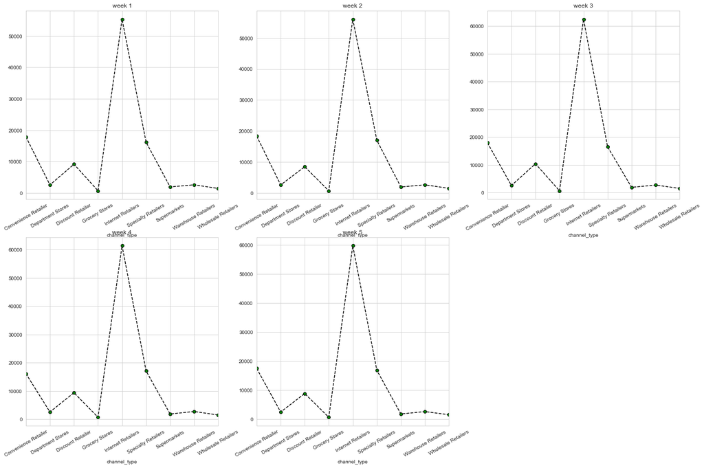

```python
fig, ax = plt.subplots(2,3, figsize=(23,15))
ax = ax.flatten()
for i in enumerate(temp,0):
    temp[i[0]].plot(ax=ax[i[0]], rot=30, marker='o', markerfacecolor='green', linestyle='dashed', color='black')
    ax[i[0]].set_title('week {}'.format(i[0]+1))
ax[5].axis('off')
plt.show()
```

internet retailers are the best performing channel consistently and by a large margin

a new feature can be made to reflect this

```python
train[['channel_type', 'store_identifier', 'product_identifier', 'category_of_route', 'supplier_identifier']].groupby('channel_type').nunique()
```

| channel_type | channel_type | store_identifier | product_identifier | category_of_route | supplier_identifier |
| --- | --- | --- | --- | --- | --- |
| Convenience Retailer | 1 | 109 | 214 | 46 | 65 |
| Department Stores | 1 | 34550 | 673 | 148 | 74 |
| Discount Retailer | 1 | 2232 | 479 | 45 | 37 |
| Grocery Stores | 1 | 548672 | 1188 | 1183 | 263 |
| Internet Retailers | 1 | 29 | 5 | 3 | 2 |
| Specialty Retailers | 1 | 3081 | 773 | 2004 | 109 |
| Supermarkets | 1 | 19676 | 647 | 364 | 149 |
| Warehouse Retailers | 1 | 22480 | 583 | 110 | 54 |
| Wholesale Retailers | 1 | 6130 | 378 | 41 | 27 |

on careful inspection, we can see that internet retailers can be specifically categorized as they have much better sales performance than other retailers and have very few unique ids associated with them

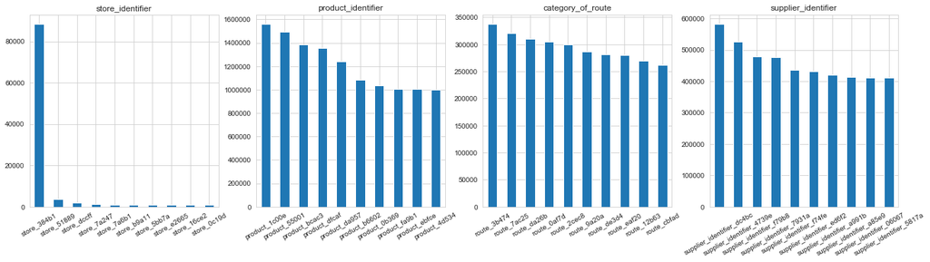

```python
# top 10 most ocurring ids in all categories
fig, ax = plt.subplots(nrows=1, ncols=4, figsize=(22,5))
for i, col in enumerate(['store_identifier', 'product_identifier', 'category_of_route', 'supplier_identifier']):
    train[str(col)].value_counts().head(10).plot.bar(ax=ax[i], rot=30)
    ax[i].set_title(col)
plt.show()
```

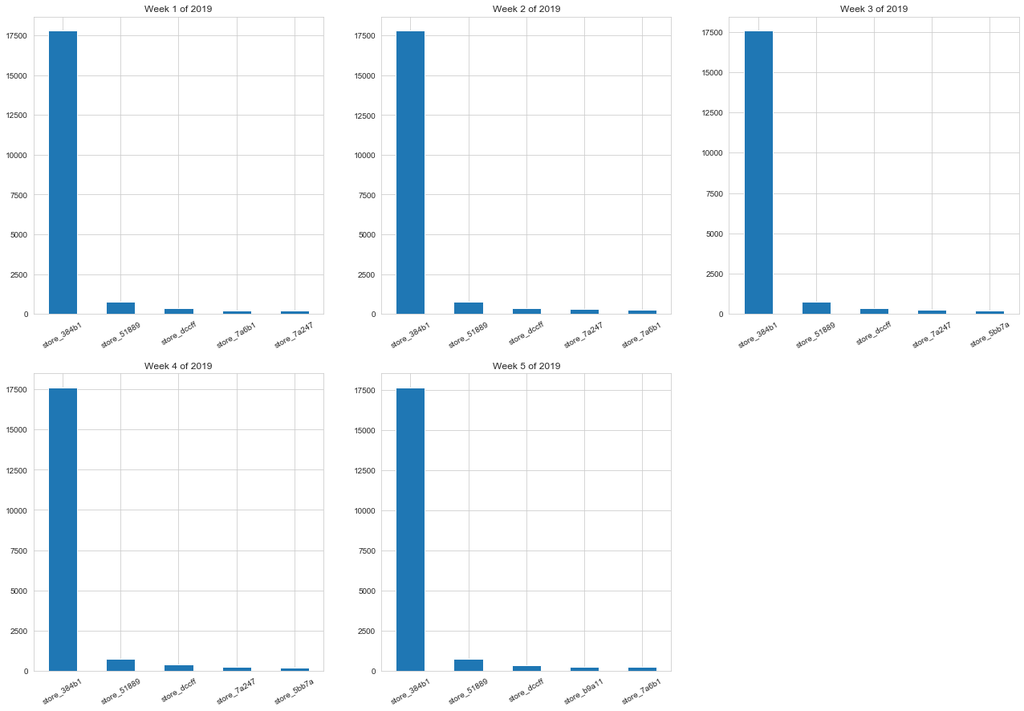

```python
fig, ax = plt.subplots(2, 3, figsize=(22, 15))
ax = ax.flatten()
for i, j in enumerate(train['experiment_week'].unique()):
    data = train.loc[train['experiment_week'] == j]
    data['store_identifier'].value_counts().head().plot.bar(ax=ax[i], rot=30)
    ax[i].set_title(j)
ax[5].axis('off')
plt.show()
# previous observation is true across all weeks
```

this implies that all forecasting will be heavily biased towards the performance of this store

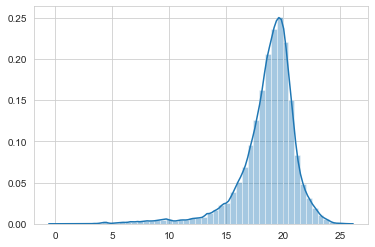

```python
val = train.loc[train['store_identifier'] == 'store_384b1', 'net_revenue']
sns.distplot(np.log(np.square([x if x != 0 else 1 for x in val])))
plt.show()
# very -vely skewed distribution
```

```python
val.describe()
```

```
count     88430.000000
mean      18547.262146
std       19384.676906
min       -4509.620000
25%        7200.000000
50%       14093.700000
75%       23328.000000
max      355468.520000
Name: net_revenue, dtype: float64
```

this store can be identified explicitly by creating a new feature

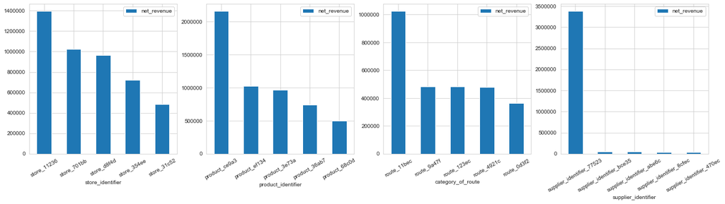

```python
# top 5 best performing ids in terms of revenue
fig, ax = plt.subplots(nrows=1, ncols=4, figsize=(22,5))
for i, col in enumerate(['store_identifier', 'product_identifier', 'category_of_route', 'supplier_identifier']):
    temp = train.groupby(col).mean()['net_revenue'].reset_index().sort_values('net_revenue', ascending=False)[:5]
    temp.plot.bar(x=col, y='net_revenue', ax=ax[i], rot=30)
plt.show()
```

supplier_identifier_77523 outclasses all other suppliers in terms of revenue performance, i.e it is the most important supplier of all (in terms of revenue)

since store_384b1 is the most prevelant in this data, there might be a relationship between this supplier and store